# Exploratory Analysis

Laurel Safranek, Salma Mohamed, Gulsima Young

## Distribution of Variables

One of the main variables that we are interested in focusing on for our project is the `che_gdp` column of the Global Health Expenditure Database. This metric stands for Current Health Expenditure (CHE) as percentage of Gross Domestic Product (GDP) (%). This is often referred to as the CHE%GDP. The CHE value explains how much a country is spending on health-related expenditures.

When we measure this as a percent of a country’s overall GDP, we are able to learn how much money the country is actively allocating towards health related funding and costs. Overall, this gives us a sense of how various countries prioritize public health.

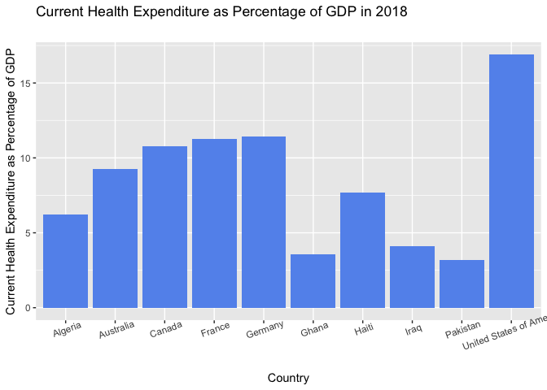

In the U.S. Health Insurance Coverage database, one of the main variables we are focusing on is the uninsurance rate. The uninsurance rate is the percentage of residents in a certain area who are not covered by health insurance (government or private). This database spans the time period directly before and after the Affordable Care Act was implemented. Therefore analyzing the change in uninsurance rate is useful in determining the impact (if any) that the legislation had on this metric in order to guide future lawmaking.

This visualization shows the uninsurance rate in a selection of states, as well as the United States as a whole, in 2010 (before the ACA) and 2015 (after the ACA). Across the all regions seen here, the uninsurance rate decrease after the Affordable Care Act was put in place.

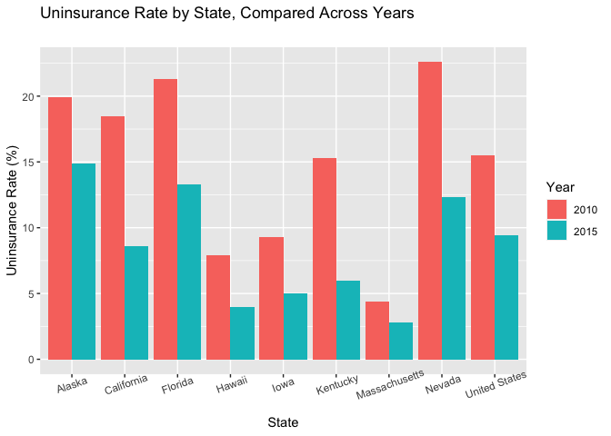

## Relationships Between Variables

In order to discover relationships between variables in the context of our project, we decided to further analyze the CHE%GDP value by comparing it with the `year` variable. This allowed us to make predictions about how the CHE%GDP would fluctuate, grow, or decline over time. We predicted that the CHE%GDP would grow steadily over time, with a couple of shifts based upon various health and economic related global events.

Though this graph does show a slight upward trend over time, it was not nearly as drastic as we thought. However, this is still vital information to have as we continue to dissect and examine our data in order to search for trends and answers to the questions that we have.

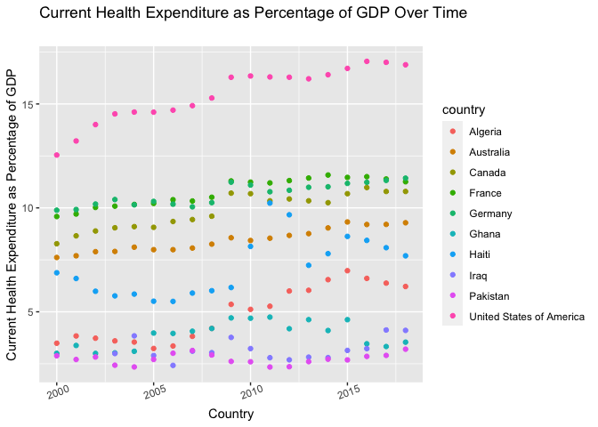

As part of the Affordable Care Act, the eligibility criteria for Medicaid were expanded to include more people. Each state could decide whether to expand Medicaid for its residents, with the federal government supplying some to all of the funding for this expansion for a period of a several years. Ultimately, some states expanded Medicaid, while other states did not.

Here, we compare the percentage of residents without health insurance coverage in states that did expand Medicaid and states that did not. We can see that in states which opted to increase Medicaid eligibility criteria, less people ended up being uninsured, possibly because they were able to be covered by Medicaid.

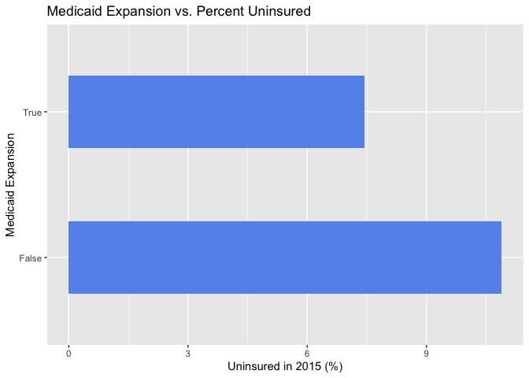